# Power and Sample Size in Logistic Regression

### Scenario 2:

#### mportion tportion and interaction are treated as ordinal, categorical variables.

sex: 1 male, 0 female

beer: 1 drank beer, 0 did not

mportion: 0 no mousse eaten, 1 some mousse eaten, 2 moderate amount eaten, 3 a lot eaten

tportion: 0 no tiramisu eaten, 1 some tiramisu eaten, 2 moderate amount eaten, 3 a lot eaten

interaction: this is mportion*tportion

```r
#Variables of interest
vars <- c("sex", "beer", "mportion", "tportion", "interaction")

#Filters out '9's which indicate missings/unknowns
subset <- na.omit(df[,c("ill",vars)])
for(i in vars){
  subset <- subset[subset[,i] != 9,]
}

#In order to work with coding conventions, there is a condition in the ccPower function
  "prob3 <- (max(X[,i]) != (length(unique(X[,i])) - 1))"
```

```
## [1] "prob3 <- (max(X[,i]) != (length(unique(X[,i])) - 1))"
```

```r
#Thus, as our interaction term is missing a "5", let's code all '6's' into 5's-
for(i in 1:nrow(subset)){
  if(subset$interaction[i] == 6){
    subset$interaction[i] <- 5
  }
}

#Ratio of controls (not ill) to cases (ill)
ratio <- (nrow(subset) - sum(subset$ill)) / sum(subset$ill)

#Group size (in this case, ungrouped = 1)
N <- rep(1,nrow(subset))

#create our design matrix
XM <- cbind(Int = 1, subset[,vars])


#Fit the data
fitM <- glm(cbind(ill, 1-ill) ~ factor(mportion) + factor(tportion) + factor(interaction) +
                                sex + beer, data=subset, family=binomial)

#Assign names to our coefficients
betaNamesM <- names(fitM$coefficients)

#Define the sample sizes to simulate
xAxis=seq(from=50, to=500, by=20)

#Remember, any variables with more than 2 levels must be coded as continous, and needs the expandX argument
ccResult <- ccPower(B=100, betaTruth=fitM$coef, X=XM, N=N, r=ratio, nCC=xAxis,
                    betaNames=betaNamesM, alpha = .1)
```

```
## 24 designs will be simulated
```

```r
#determine our observed sample size
paste0("Observed Sample Size: ", nrow(subset))
```

```
## [1] "Observed Sample Size: 236"
```

```r
#display our observed pvalues
pval <- matrix(c(summary(fitM)$coefficients[,4]),
               nrow = length(summary(fitM)$coefficients[,4]))
rownames(pval) <- betaNamesM
colnames(pval) <- "Pvalue"
pval
```

```
##                            Pvalue
## (Intercept)          6.824664e-08
## factor(mportion)1    6.741168e-03
## factor(mportion)2    1.496589e-03
## factor(mportion)3    3.992902e-03
## factor(tportion)1    3.525489e-07
## factor(tportion)2    2.799743e-08
## factor(tportion)3    9.681387e-04
## factor(interaction)1 1.243571e-01
## factor(interaction)2 1.568496e-02
## factor(interaction)3 1.330609e-01
## factor(interaction)4 8.338268e-02
## factor(interaction)5 1.430362e-02
## sex                  5.699309e-02
## beer                 1.282945e-02
```

```r
#return our results
ccResult
```

```
## Number of simulations, B: 100
## 'True' regession coefficients, betaTruth:
##    (Intercept)          -4.372714
##    factor(mportion)1     2.864605
##    factor(mportion)2     3.419018
##    factor(mportion)3     3.999130
##    factor(tportion)1     4.848094
##    factor(tportion)2     6.916703
##    factor(tportion)3     7.140635
##    factor(interaction)1 -2.086635
##    factor(interaction)2 -3.049214
##    factor(interaction)3 -2.834387
##    factor(interaction)4 -3.297756
##    factor(interaction)5 -5.556195
##    sex                   1.072406
##    beer                 -1.381900
##
## Power
##               (Intercept) factor(mportion)1 factor(mportion)2
## CD                     98              99.0              99.0
## CC n = 50               0              11.1              55.6
## CC n = 70               0               5.6              63.9
## CC n = 90               0              43.1              81.0
## CC n = 110              0              47.4              82.9
## CC n = 130              0              68.6              87.2
## CC n = 150              0              69.1              91.8
## CC n = 170              0              76.3              96.9
## CC n = 190              0              84.5              95.9
## CC n = 210              0              86.0              97.0
## CC n = 230              0              93.0              98.0
## CC n = 250              0              95.0              96.0
## CC n = 270              0              95.0              99.0
## CC n = 290              0              94.0              99.0
## CC n = 310              0              96.0              99.0
## CC n = 330              0              96.0              99.0
## CC n = 350              0              99.0              99.0
## CC n = 370              0              99.0              99.0
## CC n = 390              0              99.0              99.0
## CC n = 410              0              99.0              99.0
## CC n = 430              0              99.0              99.0
```

[output cut: 114 more lines]

```
## CC n = 210     0
## CC n = 230     0
## CC n = 250     0
## CC n = 270     0
## CC n = 290     0
## CC n = 310     0
## CC n = 330     0
## CC n = 350     0
## CC n = 370     0
## CC n = 390     0
## CC n = 410     0
## CC n = 430     0
## CC n = 450     0
## CC n = 470     0
## CC n = 490     0
```

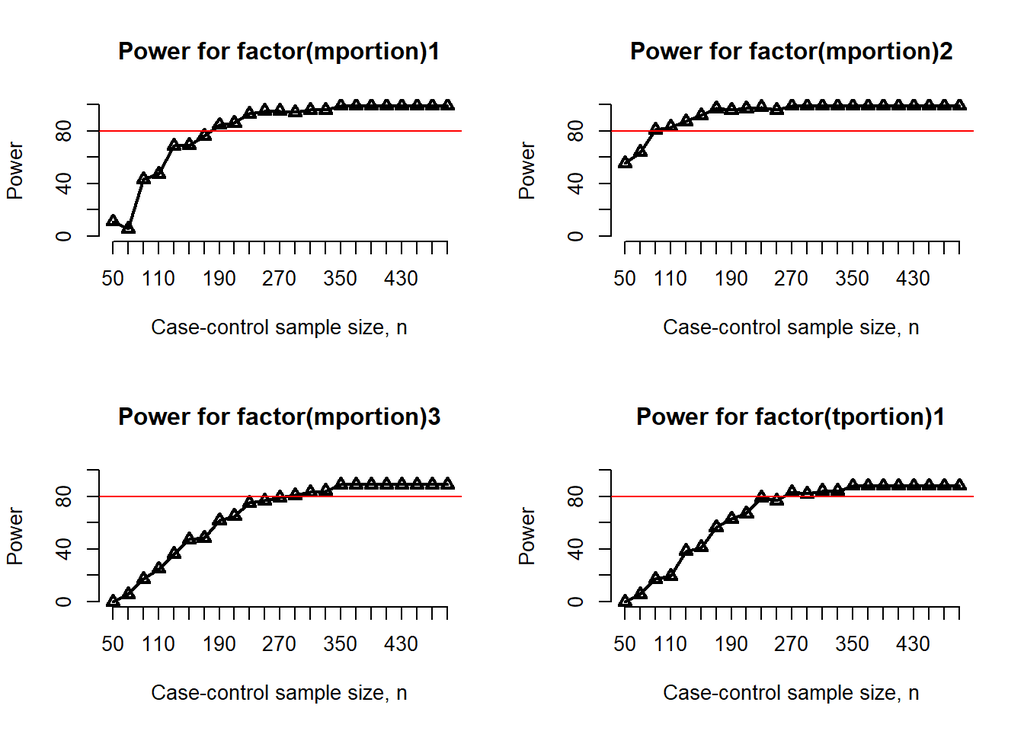

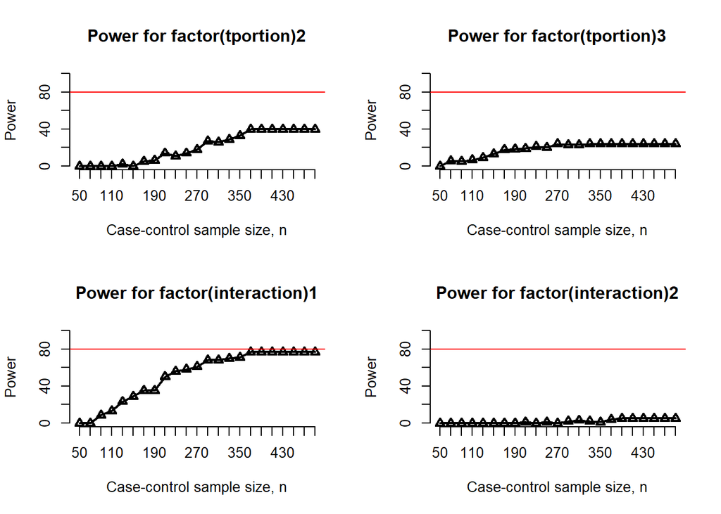

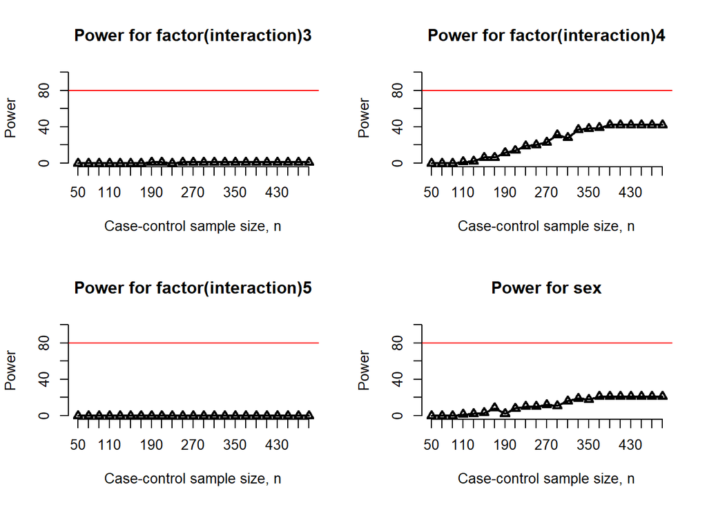

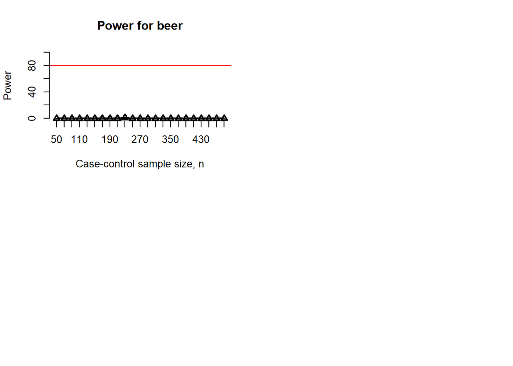

```r
#Plot our results
par(mfrow=c(2,2))
for(i in 2:length(ccResult$betaTruth)){
plotPower(ccResult, coefNum=i, xAxis = xAxis)
abline(h = 80, col = "red")
}
```

Overall, this ccPower() function fails when it comes to including multi-level interactions with ordinal variables. Interaction effects must be coded manually, and the function cannot differentiate between, for example, mportion2*tportion1 vs. mportion1*tportion2; both are incorporated into interaction2. Additionally, we had to completely re-code the interaction between mportion3*tportion3 as if it was level 5 (instead of 6). The interpretation is complicated, and there are far too many plots to provide consise visual summaries. Our model inferences are not reflected by the power simulations. Given that tiramisu is truly the ‘culprit’, our ccPower() function does not indicate that we would achieve sufficient power.

### Scenario 3:

#### Nested model with binary terms for mportion and tportion and interaction

sex: 1 male, 0 female

beer: 1 drank beer, 0 did not

mousse: 1 ate mousse, 0 did not

tira: 1 ate tira, 0 did not

interaction1: 1 if ate both mousse and tira, 0 if ate only one or neither

```r
#variables of interest
vars <- c("sex", "beer", "mousse", "tira", "interaction1")

#filters out '9's which indicate missings/unknowns
subset <- na.omit(df[,c("ill",vars)])
for(i in vars){
  subset <- subset[subset[,i] != 9,]
}

#ratio of controls (not ill) to cases (ill)
ratio <- (nrow(subset) - sum(subset$ill)) / sum(subset$ill)

#group size (in this case, ungrouped = 1)
N <- rep(1,nrow(subset))

#create our design matrix
XM <- cbind(Int = 1, subset[,vars])

#assign names to our coefficients

#Fit the data
fitM <- glm(cbind(ill, 1-ill) ~ mousse + tira + interaction1 +
                                sex + beer, data=subset, family=binomial)
#assign names
betaNamesM <- names(fitM$coefficients)

#Define the sample sizes to simulate
xAxis=seq(from=50, to=500, by=20)

#remember, any variables with more than 2 levels must be coded as continous, and needs the expandX argument
ccResult <- ccPower(B=100, betaTruth=fitM$coef, X=XM, N=N, r=ratio, nCC=xAxis,
                    betaNames=betaNamesM, alpha = .1)
```

```
## 24 designs will be simulated
```

```r
#determine our observed sample size
paste0("Observed Sample Size: ", nrow(subset))
```

```
## [1] "Observed Sample Size: 239"
```

```r
#display our observed pvalues
pval <- matrix(c(summary(fitM)$coefficients[,4]),
               nrow = length(summary(fitM)$coefficients[,4]))
rownames(pval) <- betaNamesM
colnames(pval) <- "Pvalue"
pval
```

```
##                    Pvalue
## (Intercept)  2.335605e-08
## mousse       2.835635e-04
## tira         1.057066e-09
## interaction1 7.969221e-03
## sex          2.674546e-02
## beer         1.544517e-02
```

```r
#return our results
ccResult
```

```
## Number of simulations, B: 100
## 'True' regession coefficients, betaTruth:
##    (Intercept)  -4.464863
##    mousse        3.294570
##    tira          5.559869
##    interaction1 -2.861733
##    sex           1.164292
##    beer         -1.284879
##
## Power
##               (Intercept) mousse tira interaction1 sex beer
## CD                     89   89.0 85.0           61  54   26
## CC n = 50               0   16.3 12.2            0   0    0
## CC n = 70               0   34.0 33.0            3   5    2
## CC n = 90               0   40.0 38.0            5  14    3
## CC n = 110              0   57.0 49.0           14  23    7
## CC n = 130              0   61.0 55.0           26  29   11
## CC n = 150              0   69.0 61.0           31  37   14
## CC n = 170              0   77.0 70.0           36  36   19
## CC n = 190              0   78.0 73.0           47  42   20
## CC n = 210              0   83.0 80.0           50  50   24
## CC n = 230              0   86.0 82.0           57  54   24
## CC n = 250              0   89.0 84.0           60  52   25
## CC n = 270              0   89.0 85.0           60  55   27
## CC n = 290              0   89.0 85.0           61  54   26
## CC n = 310              0   89.0 85.0           61  54   26
## CC n = 330              0   89.0 85.0           61  54   26
## CC n = 350              0   89.0 85.0           61  54   26
## CC n = 370              0   89.0 85.0           61  54   26
## CC n = 390              0   89.0 85.0           61  54   26
## CC n = 410              0   89.0 85.0           61  54   26
## CC n = 430              0   89.0 85.0           61  54   26
## CC n = 450              0   89.0 85.0           61  54   26
## CC n = 470              0   89.0 85.0           61  54   26
## CC n = 490              0   89.0 85.0           61  54   26
##
## Number of failed repititions
## CD            0
## CC n = 50     2
## CC n = 70     0
## CC n = 90     0
## CC n = 110    0
## CC n = 130    0
## CC n = 150    0
## CC n = 170    0
## CC n = 190    0
## CC n = 210    0
## CC n = 230    0
## CC n = 250    0
## CC n = 270    0
## CC n = 290    0
## CC n = 310    0
## CC n = 330    0
## CC n = 350    0
## CC n = 370    0
## CC n = 390    0
## CC n = 410    0
## CC n = 430    0
## CC n = 450    0
## CC n = 470    0
## CC n = 490    0
```

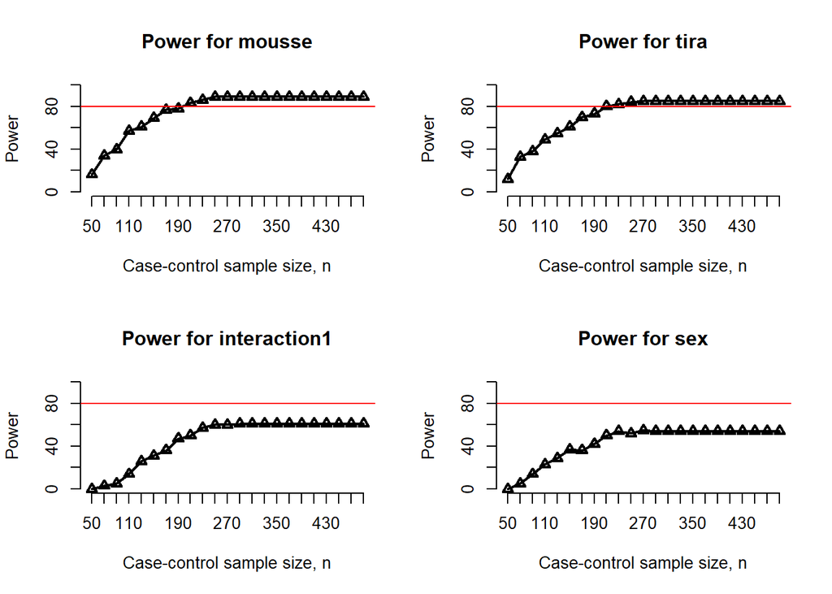

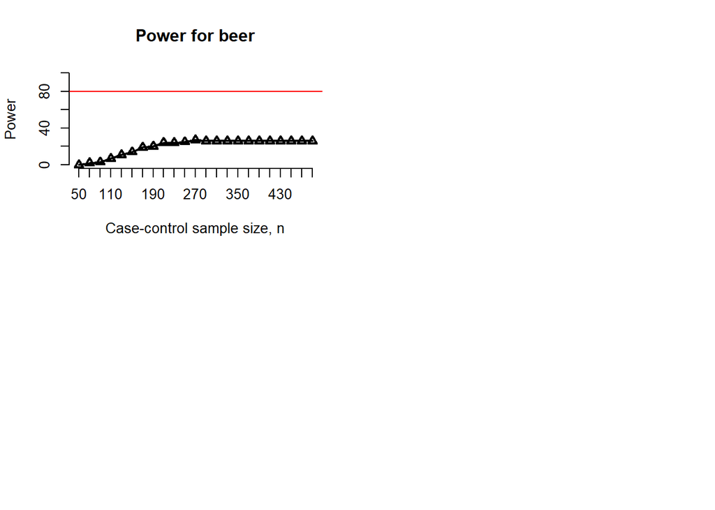

```r
par(mfrow=c(2,2))
for(i in 2:length(ccResult$betaTruth)){
plotPower(ccResult, coefNum=i, xAxis = xAxis)
abline(h = 80, col = "red")
}
```

Note that we are dealing with a sample size of n = 239 now, which we can still (conservatively) approximate with n = 230.

This model so far is probably our best; we fail to achieve sufficient power for the insignificant variables sex, beer, and interaction, whereas our scenario 1 appeared to be overpowered to some extent. This model properly achieves sufficient power only for mousse and tira at our observed sample size. When placed in the context of the problem, treating mousse and tira as indicators and not continous or ordinal is the most consistent way to code the variable across subjects. Unlike scenario two, the plots and ouput from the ccPower() function are easy to interpret and visualize.

### Scenario 4:

#### Grouped data

mousse: 1 ate mousse, 0 did not

tira: 1 ate tira, 0 did not

We will now use B = 1000 and nCC = seq(from=25, to=275, by=25) to better illustrate comparisons between grouped vs. ungrouped power.

```r
#variables of interest
vars <- c("mousse", "tira")
group1 <- with(subset, subset[ill == 1 & mousse == 1 & tira == 1,])
group2 <- with(subset, subset[ill == 1 & mousse == 1 & tira == 0,])
group3 <- with(subset, subset[ill == 1 & mousse == 0 & tira == 1,])
group4 <- with(subset, subset[ill == 1 & mousse == 0 & tira == 0,])

group5 <- with(subset, subset[ill == 0 & mousse == 1 & tira == 1,])
group6 <- with(subset, subset[ill == 0 & mousse == 1 & tira == 0,])
group7 <- with(subset, subset[ill == 0 & mousse == 0 & tira == 1,])
group8 <- with(subset, subset[ill == 0 & mousse == 0 & tira == 0,])

n1 <- nrow(group1)
n2 <- nrow(group2)
n3 <- nrow(group3)
n4 <- nrow(group4)
n5 <- nrow(group5)
n6 <- nrow(group6)
n7 <- nrow(group7)
n8 <- nrow(group8)

grouped <- cbind(c(1:4),
      c(1,1,0,0),
      c(1,0,1,0),
      c(n1 + n5, n2 + n6, n3 + n7, n4 + n8),
      c(n1, n2, n3, n4))
colnames(grouped) <- c("group","mousse","tira","n","case")

#create our design matrix
XM <- cbind(Int = 1, grouped[,vars])

#assign names to our coefficients

#Fit the data
fitM1 <- glm(cbind(case, n-case) ~ mousse + tira, data=data.frame(grouped), family=binomial)

betaNamesM1 <- names(fitM1$coefficients)

#Define the sample sizes to simulate
xAxis=seq(from=25, to=275, by=25)

#remember, any variables with more than 2 levels must be coded as continous, and needs the expandX argument
ccResult1 <- ccPower(B=1000, betaTruth=fitM1$coef, X=XM, N=grouped[,"n"], r=ratio, nCC=xAxis,
                    betaNames=betaNamesM1, alpha = .1)
```

```
## 12 designs will be simulated
```

```r
fitM2 <- glm(cbind(ill, 1-ill) ~ mousse + tira, data=subset, family=binomial)
betaNamesM2 <- names(fitM2$coefficients)
XM <- cbind(Int = 1, subset[,vars])
N <- rep(1, nrow(subset))

#remember, any variables with more than 2 levels must be coded as continous, and needs the expandX argument
ccResult2 <- ccPower(B=1000, betaTruth=fitM2$coef, X=XM, N=N, r=ratio, nCC=xAxis,
                    betaNames=betaNamesM2, alpha = .1)
```

```
## 12 designs will be simulated
```

```r
#determine our observed sample size
paste0("Observed Sample Size: ", sum(N))
```

```
## [1] "Observed Sample Size: 239"
```

```r
cat('\n')
```

```r
#display our observed pvalues
pval1 <- matrix(c(summary(fitM1)$coefficients[,4]),
               nrow = length(summary(fitM1)$coefficients[,4]))
rownames(pval1) <- betaNamesM1
colnames(pval1) <- "Pvalue Grouped"
pval1
```

```
##             Pvalue Grouped
## (Intercept)   6.961466e-15
## mousse        3.522294e-03
## tira          2.112709e-14
```

```r
pval2 <- matrix(c(summary(fitM2)$coefficients[,4]),
               nrow = length(summary(fitM2)$coefficients[,4]))
rownames(pval2) <- betaNamesM2
colnames(pval2) <- "Pvalue Ungrouped"
pval2
```

```
##             Pvalue Ungrouped
## (Intercept)     6.915348e-15
## mousse          3.521361e-03
## tira            2.104036e-14
```

```r
#return our results
ccResult1
```

```
## Number of simulations, B: 1000
## 'True' regession coefficients, betaTruth:
##    (Intercept) -3.246219
##    mousse       1.308489
##    tira         3.717479
##
## Power
##               (Intercept) mousse  tira
## CD                    100   88.4 100.0
## CC n = 25               0   10.8  29.1
## CC n = 50               0   35.9  72.8
## CC n = 75               0   51.0  89.2
## CC n = 100              0   58.3  96.4
## CC n = 125              0   66.3  97.9
## CC n = 150              0   74.1  99.3
## CC n = 175              0   77.5  99.9
## CC n = 200              0   84.2 100.0
## CC n = 225              0   86.5 100.0
## CC n = 250              0   88.0 100.0
## CC n = 275              0   88.4 100.0
##
## Number of failed repititions
## CD            0
## CC n = 25     5
## CC n = 50     0
## CC n = 75     0
## CC n = 100    0
## CC n = 125    0
## CC n = 150    0
## CC n = 175    0
## CC n = 200    0
## CC n = 225    0
## CC n = 250    0
## CC n = 275    0
```

```r
ccResult2
```

```
## Number of simulations, B: 1000
## 'True' regession coefficients, betaTruth:
##    (Intercept) -3.246219
##    mousse       1.308489
##    tira         3.717479
##
## Power
##               (Intercept) mousse  tira
## CD                    100   86.7 100.0
## CC n = 25               0   11.0  29.6
## CC n = 50               0   34.8  73.5
## CC n = 75               0   43.2  85.9
## CC n = 100              0   59.1  95.4
## CC n = 125              0   64.2  97.8
## CC n = 150              0   71.4  99.3
## CC n = 175              0   76.2  99.8
## CC n = 200              0   80.1  99.9
## CC n = 225              0   84.0 100.0
## CC n = 250              0   86.1 100.0
## CC n = 275              0   86.7 100.0
##
## Number of failed repititions
## CD            0
## CC n = 25     3
## CC n = 50     0
## CC n = 75     0
## CC n = 100    0
## CC n = 125    0
## CC n = 150    0
## CC n = 175    0
## CC n = 200    0
## CC n = 225    0
## CC n = 250    0
## CC n = 275    0
```

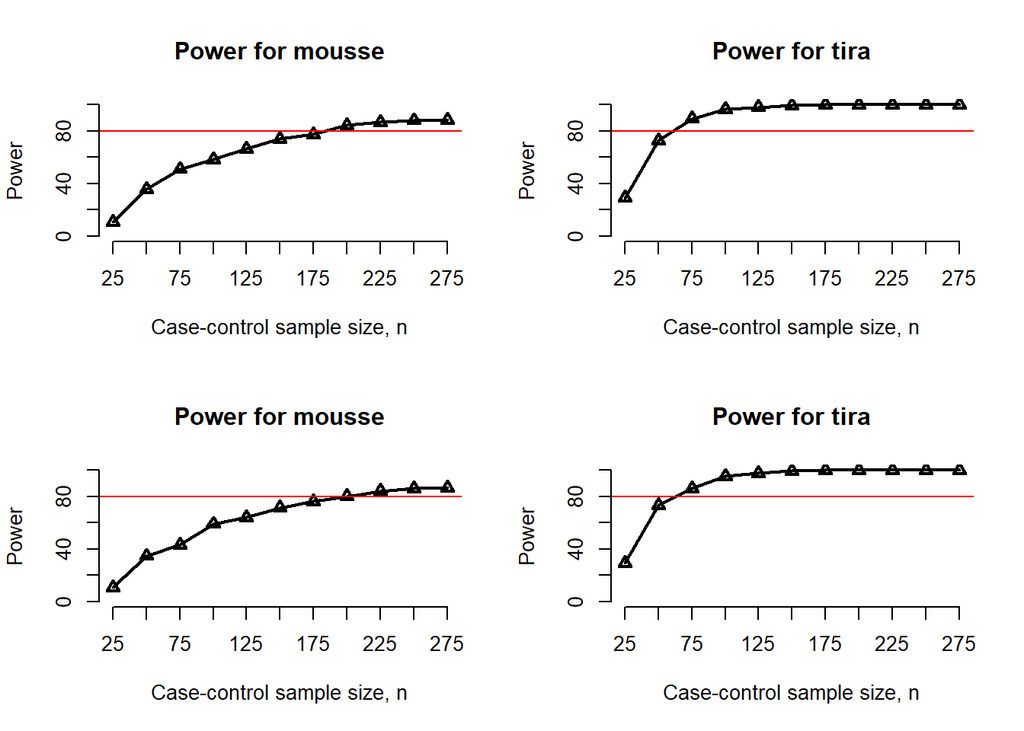

```r
par(mfrow=c(2,2))
for(i in 2:length(ccResult1$betaTruth)){
plotPower(ccResult1, coefNum=i, xAxis = xAxis)
abline(h = 80, col = "red")
}
for(i in 2:length(ccResult2$betaTruth)){
plotPower(ccResult2, coefNum=i, xAxis = xAxis)
abline(h = 80, col = "red")
}
```

For this scenario, we are comparing grouped vs. ungrouped data. Our model fit and parameter estimates should not change, and neither should our power simulations. Our observed sample size here is 239, and we’ve only included 2 predictors here for convenience; mousse and tira.

Power for mousse and tira: We notice that by n = 200 we’ve achieved 80% sufficient power for both simulations for mousse, and by larger sample sizes, power seems to converge to ~ 86%. For tira, we notice that by n = 125 we’ve achieved virtually perfect power, approximated to 100% by the ccPower() function. Interestingly, the treatment effect for both mousse and tira are much smaller than previously seen in all of the other scenarios, although our general trend we saw in the normal simulations was that increasing treatment effect increases power.

### Overall Conclusions in comparing Power Simulations: Normal vs. Case-Control

While certainly controlling for some known covariates may theoretically reduce noise in our data and help increase power for variables of interest (like we saw in the normal simulations), when it comes to actually using real data (such as in our case-control scenario) this becomes much more complicated. As we’ve seen, the way we formulate our model dramatically changes the power of our experiment for each predictor as well as overall interpretations. Contrary to what we’d expect from our normal simulations, our greatest power for tira was observed when we controlled for less covariates, did not include any interactions, and with a smaller predicted treatment effect. This does not suggest that the relationships we outlined with the normal simulations are incorrect; rather, it implies that the way we formulate our model and code our data is critically important, and these relationships only hold when all else is held constant.

### Overall conclusions of ccPower() function:

Pros:

1. Constructing one’s own simulation is difficult and time consuming. This function is trustworthy and convenient for people without advanced programming skills to use.
2. plotPower function included in osDesign package is easy to use and very effective at visualizing power simulations.
3. Documentation is thorough and straightforward; when I ran into trouble with the function, by looking at the original source code and osDesign documentation, it was easy to find where mistakes occurred.

Cons:

1. The function is very inflexible, which sometimes makes fitting models frustrating. Most of these problems were illustrated in Scenario 2.
   1. If a categorical variable has coded levels 0:4 but the only observed values are 0,1,2,4, the function will return an error as “3” isn’t included.
   2. The coding scheme will not work if a baseline category isn’t coded as 0.
   3. An interaction term will not be handled by the function; it must be manually coded as its own variable in the design matrix and glm() function.
   4. expandX on all the categorical variables has to used even if only one continuous variable is present.
2. The parameters for the function (ie design matrix, beta coefficients) must be manually created. While this should provide freedom and flexibility, it more often than not runs into conflict with the expectations of the function.
3. This function relies on Wald Test, which is inferior to LR test at small sample sizes. It would not be difficult and it would be convenient to include an option to use a different testing procedure.
4. The function cannot handle any missing data, which makes its use on any real dataset nearly impossible without substantial data reduction, which may bias any results.
5. One must manually specify any multiple-comparison alpha adjustments by literally changing the alpha value parameter beforehand.

### References

Grieve, A. P., & Sarker, S. J. (2016). Simulation based sample sizing and power calculations in logistic regression with partial prior information. Pharmaceutical statistics, 15(6), 507-516.

Novikov, I., Fund, N., & Freedman, L. S. (2010). A modified approach to estimating sample size for simple logistic regression with one continuous covariate. Statistics in medicine, 29(1), 97-107.

Demidenko, E. (2007). Sample size determination for logistic regression revisited. Statistics in medicine, 26(18), 3385-3397.

Abramowitz M, Stegun IA. (1984) Pocketbook of mathematical functions (abridged edition of handbook of mathematical functions). Harri Deutsch Verlag: Thun.

Whittemore, A. S. (1981). Sample size for logistic regression with small response probability. Journal of the American Statistical Association, 76(373), 27-32.

Hsieh, F. Y., Bloch, D. A., & Larsen, M. D. (1998). A simple method of sample size calculation for linear and logistic regression. Statistics in medicine, 17(14), 1623-1634.